# Exploratory Data Analysis

```r
library(tidyverse)
```

# Introduction

- I’ve actually forgotten most of the data collection
- We have some hypotheses we want to test
  - He says parts the less he understands the material. Perhaps as the semester progresses? Or perhaps we can *infer* what parts of the course material he doesn’t understand by fitting model?

# Visualizations

```r
# Read in tidied data.
col_types <- cols(
  week.number = col_double(),
  day = col_character(),
  parts = col_double()
)
data <- read_csv("../data/tidy/parts.csv", col_types = col_types)
```

```r
summary(data$parts)
```

```
   Min. 1st Qu.  Median    Mean 3rd Qu.    Max.    NA's
   0.00   16.00   21.00   24.03   32.00   78.00       7
```

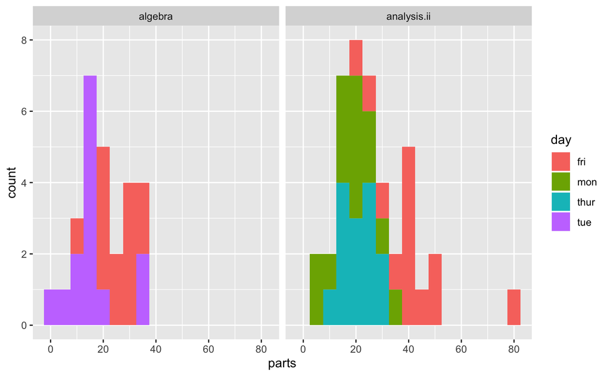

```r
# Visualize part counts for analysis and algebra, respectively.
ggplot(data) +
  geom_histogram(aes(parts, fill = day), position = "stack", binwidth = 5) +
  facet_wrap(~ class)
```

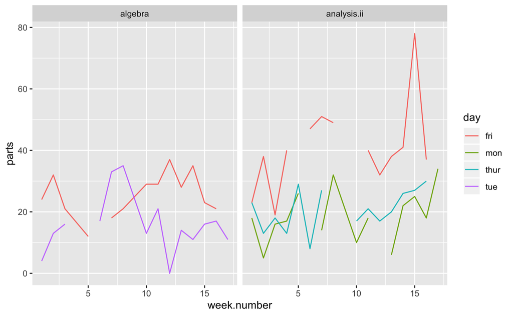

```r
# Visualize time dependence of parts!
ggplot(data) +
  geom_line(aes(x = week.number, y = parts, color = day)) +
  facet_wrap(~ class)
```

# Notes and Observations

1. The raw (untidied) data had NaNs (a.k.a. “non-finite values”): there are several possible reasons for these missing values:
   1. The Flood (4th week of Modern Algebra)
   2. Spring breaks (9th week of the spring semester)
   3. Days with midterms or finals (when I too busy flunking the exam to keep count of the number of parts)
   4. I missed the class?

   In the first two cases, the missing days have been removed by `tidy_data.R`: `week.number` simply skips the appropriate week (e.g. it jumps from week 8 to 10 to reflect that the 9th week of the spring semester is spring break).
2. Looking at the histogram, it doesn’t look like there’s any [zero-inflation](https://en.wikipedia.org/wiki/Zero-inflated_model) (i.e. there isn’t a spike at 0, which one might expect). This is amazing: when we model the parts data, we will not need to give special consideration for days in which he said no parts!
3. Since each lecture didn’t have the same number of hours, some days have a different distribution of parts than others. Specifically, Friday lectures were two hours long, whereas all other lectures were one hour long.
4. There also looks like theres some decent dependence on time! This might lend some support to the joke/idea that as the semester went on, the less the professor understood the material he was delivering, and so the more parts there were.